# BIOST 561: function design

# A brief aside about S3 generics in R

The result of `stats::lm()` actually are of class `lm`.

```r
class(lm_D9)
```

```
## [1] "lm"
```

It’s actually more than just a list!

Furthermore, when you call `print(lm_D9)`, you’re actually using the function `print.lm()`. See https://github.com/SurajGupta/r-source/blob/master/src/library/stats/R/lm.R#L248

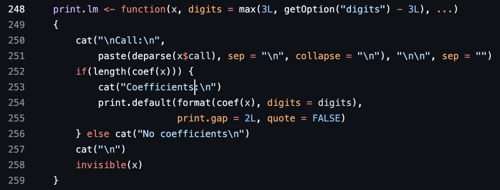

But… how did we actually end up using `print.lm()` without explicitly calling it?

- There’s actually **many** print functions in R.
- Each one is for a specific class.
  - This is why I wouldn’t use `.` to separate words in your function name. The `.` has a special meaning in R. The usual structure is `[function_name].[class]`.

```r
methods("print")
```

```
##   [1] print.acf*
##   [2] print.activeConcordance*
##   [3] print.AES*
##   [4] print.all_vars*
##   [5] print.anova*
##   [6] print.any_vars*
##   [7] print.aov*
##   [8] print.aovlist*
##   [9] print.ar*
##  [10] print.Arima*
##  [11] print.arima0*
##  [12] print.AsIs
##  [13] print.aspell*
##  [14] print.aspell_inspect_context*
##  [15] print.bibentry*
```

[output cut: 345 more lines]

- The `print()`, `plot()`, and `summary()` functions are actually “generics”.
- You can see how `print()` is defined in base R (see https://github.com/SurajGupta/r-source/blob/master/src/library/base/R/print.R):

```r
print <- function(x, ...) UseMethod("print")
```

- This `UseMethod()` function means: whenever the `print()` function is called, R looks up the class of the first argument and “dispatches” the correct `print.[class]` function.
- For most generic functions, there’s usually a `default` function. For example, `print.default()` is the print statement that is used when R cannot find a suitable other `print()` function to use. See https://github.com/SurajGupta/r-source/blob/master/src/library/base/R/print.R#L22)

# Defining your own class via `structure()`

- Look at https://adv-r.hadley.nz/s3.html#s3-methods on how to write your own generic functions.
  - There’s a few rules you need to abide by
- If you wanted to define your own class (for example, class `UW561`, so you can write your own `print.UW561()` function):

```r
create_561 <- function(string){
  structure(string,
            class = "UW561")
}

print.UW561 <- function(x, ...){
  paste("Our custom 561 print statement:", x)
}

result <- create_561("test")
result
```

[output not shown]

You can do this with all your fancy results!

If you want to enumerate all the generic functions, see https://stackoverflow.com/questions/15803154/see-which-s3-generic-methods-are-available-in-environment

```r
objs1 <- mget(ls("package:base"), inherits=TRUE)
funs1 <- Filter(is.function, objs1)
genFuns0 <- sapply(
  funs1,
  function(X) {
    if (!is.null(body(X)) & !is.symbol(body(X))) {
      utils::isS3stdGeneric(X)
    }
  },
  simplify=FALSE
)
sort(names(Filter(isTRUE, genFuns0)))
```

```
##  [1] "%*%"                      "anyDuplicated"
##  [3] "as.array"                 "as.Date"
##  [5] "as.expression"            "as.function"
##  [7] "as.list"                  "as.matrix"
##  [9] "as.null"                  "as.POSIXct"
## [11] "as.POSIXlt"               "as.single"
## [13] "as.table"                 "by"
## [15] "chol"                     "chooseOpsMethod"
## [17] "close"                    "conditionCall"
## [19] "conditionMessage"         "crossprod"
## [21] "cut"                      "date"
## [23] "determinant"              "diff"
## [25] "droplevels"               "duplicated"
## [27] "flush"                    "getDLLRegisteredRoutines"
## [29] "intersect"                "is.na<-"
```

[output cut: 21 more lines]

If you write your own class, you can then write your class’s specific version for any of these!

# We’re done with the lecture. A few more things: Piping

- See https://www.tidyverse.org/blog/2023/04/base-vs-magrittr-pipe/ for current updates on piping

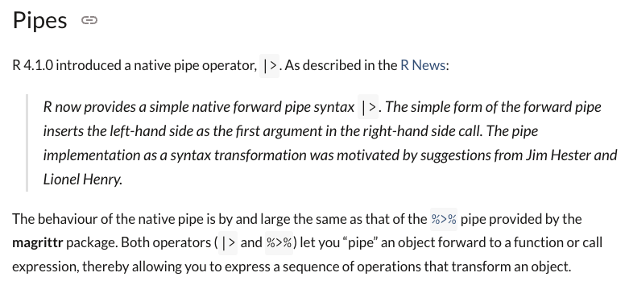

- See https://renkun-ken.github.io/pipeR/ for crazy usage of pipes (but I would not recommend this at all)

# More on R packages

- Functions:
  - https://adv-r.hadley.nz/functions.html: **VERY** useful
- CRAN checks:
  - https://bookdown.org/rdpeng/RProgDA/passing-cran-checks.html
  - https://kbroman.org/pkg_primer/pages/check.html
- S3 objects:
  - https://bookdown.dongzhuoer.com/hadley/r-pkgs/namespace
  - Note, exporting S3 generics is a bit trick. See https://roxygen2.r-lib.org/articles/namespace.html#s3.

# With the remaining time…

- Next week: My favorite topic of all of coding – unit tests! I’ll be very opinionated about this topic since I live-and-die by it.
- We’re changing rooms again. We’ll be in HRC 342 next week.